# Aula 24 - Regressão simples

Cléber Figueiredo

2024-10-24

## Exercício 1

1. Construa o diagrama de dispersão entre SAC (complaint handling) e confiança (trust).

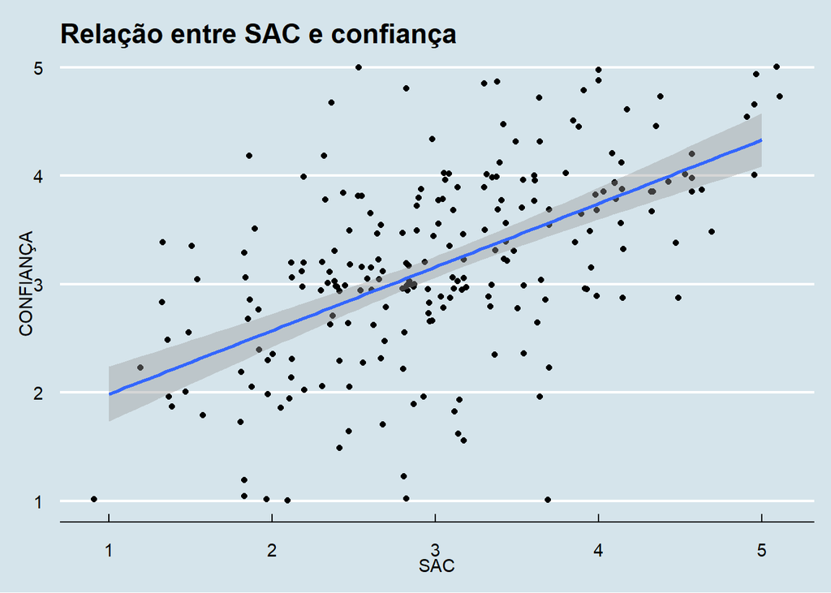

O gráfico mostra que quanto maior a nota dada ao SAC, maior a confiança do consumidor no serviço de TV por assinatura.

2. Calcule a correlação e analise-a.

```
## [1] 0.559611
```

O efeito da nota dada ao SAC sobre a confiança é moderado, já que a correlação é igual a 0,56.

3. Encontre a equação de regressão e interprete a inclinação da reta.

|  | Estimate | Std. Error | t value | Pr(>\|t\|) |
| --- | --- | --- | --- | --- |
| (Intercept) | 1.4012622 | 0.1838056 | 7.62361 | 0 |
| x | 0.5858305 | 0.0582285 | 10.06089 | 0 |

Na coluna estimate aparecem os valores dos coeficientes linear (1.40) e o angular (0.59).

A equação fica
$$Confiança = 1.40 +
0.59*SAC.$$

O coeficiente angular igual a 0.59 indica quando, em média, aumenta a nota da confiança por unidade de nota dada ao SAC.

|  | 2.5 % | 97.5 % |
| --- | --- | --- |
| (Intercept) | 1.04 | 1.76 |
| x | 0.47 | 0.70 |

O valor do coeficiente angular 0.59 é uma média. Esse coeficiente pode ser qualquer valor entre 0.47 e 0.70 com 95% de confiança.

4. Estime a confiança de um consumidor que dá nota 2 ao serviço de atendimento ao consumidor.

| fit | lwr | upr |
| --- | --- | --- |
| 2.572923 | 2.418816 | 2.727031 |

A previsão apresenta três valores

fit (valor realista): é o valor que bastaria você substituir na equação. É o valor médio. lwr (lower - pessimista): é a pior confiança estimada para o consumidor que dá nota 2 ao SAC. upr (upper - otimista): é a melhor confiança estimada para o consumidor que dá nota 2 ao SAC.